# Assignment 4: Text clustering

Authors

Ezra Gerris

Ana Melchor Perez

Published

November 5, 2023

```r
data("movie_review")
```

# Data description

We began our data exploration by identifying the size of our dataset (which contains 5,000 entries) and verified that each of the IDs in the dataset were unique. Apart from the review ID column, this data contains a “sentiment” column representing sentiment labels. These binary labels have a mean sentiment score of approximately 0.5034, indicating a relatively balanced distribution of positive and negative sentiments. Lastly, the “review” column contains the textual data that form the actual movie reviews.

```r
dim(movie_review)
```

```
[1] 5000    3
```

```r
names(movie_review)
```

```
[1] "id"        "sentiment" "review"
```

```r
mean(movie_review$sentiment)
```

```
[1] 0.5034
```

```r
unique_ids <- movie_review %>%
  select(id) %>%
  unique()


num_unique_ids <- nrow(unique_ids)
cat("Number of unique items in the column:", num_unique_ids) #this means every id is unique
```

```
Number of unique items in the column: 5000
```

We were interested in some of the common words in these reviews and therefore created a word cloud that highlighted typical movie review terms such as story, plot, time, characters, show, etc.

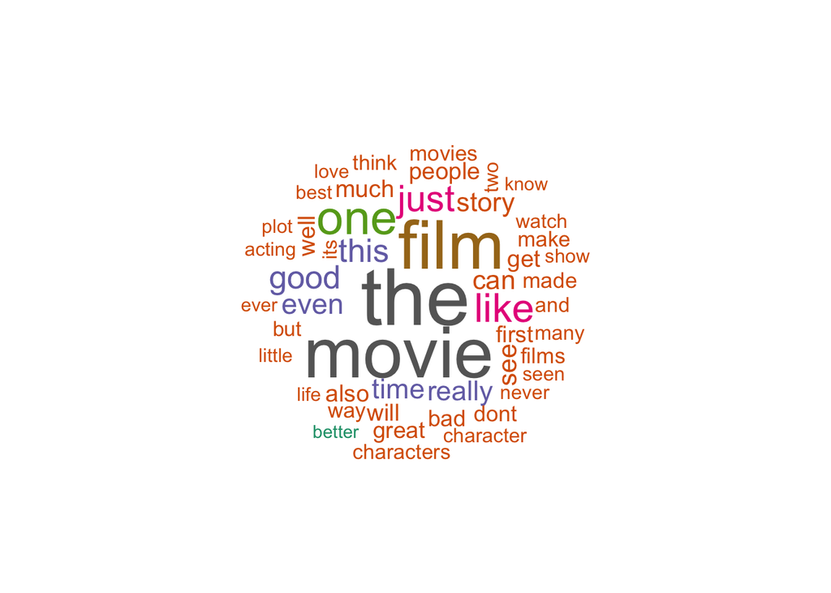

```r
movie_review %$% wordcloud(review,
                           min.freq = 10,
                           max.words = 50,
                           random.order = FALSE,
                           colors = brewer.pal(8, "Dark2"))
```

Moreover, we were interested in the distribution of lengths of the movie reviews and therefore plotted them in a histogram (shown below)

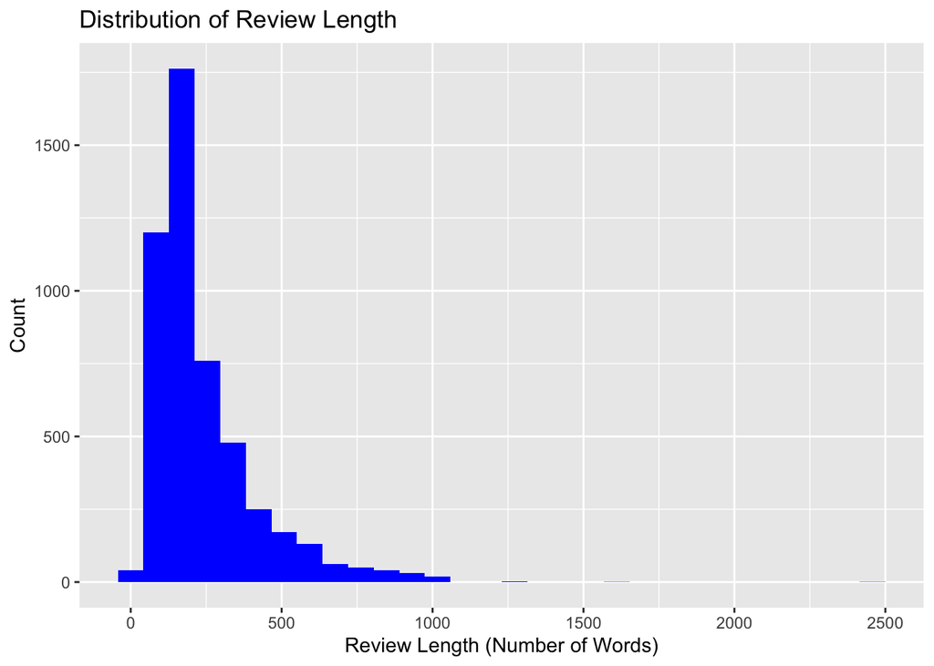

```r
movie_review$review_length <- sapply(strsplit(movie_review$review, " "), length)

ggplot(movie_review, aes(x = review_length)) +
  geom_histogram(fill = "blue") +
  labs(
    title = "Distribution of Review Length",
    x = "Review Length (Number of Words)",
    y = "Count"
  )
```

From the word length distribution graph on the left, it is evident that there are a few extreme outliers that have review lengths of greater than approximately 1200. Currently, it seems as though the word length distribution is skewed right, but we wanted to confirm this was not simply caused by a few outliers. Consequently, we removed any rows with reviews greater than 1200 words from the dataset and plotted the word length distribution once again. This plot is shown below.

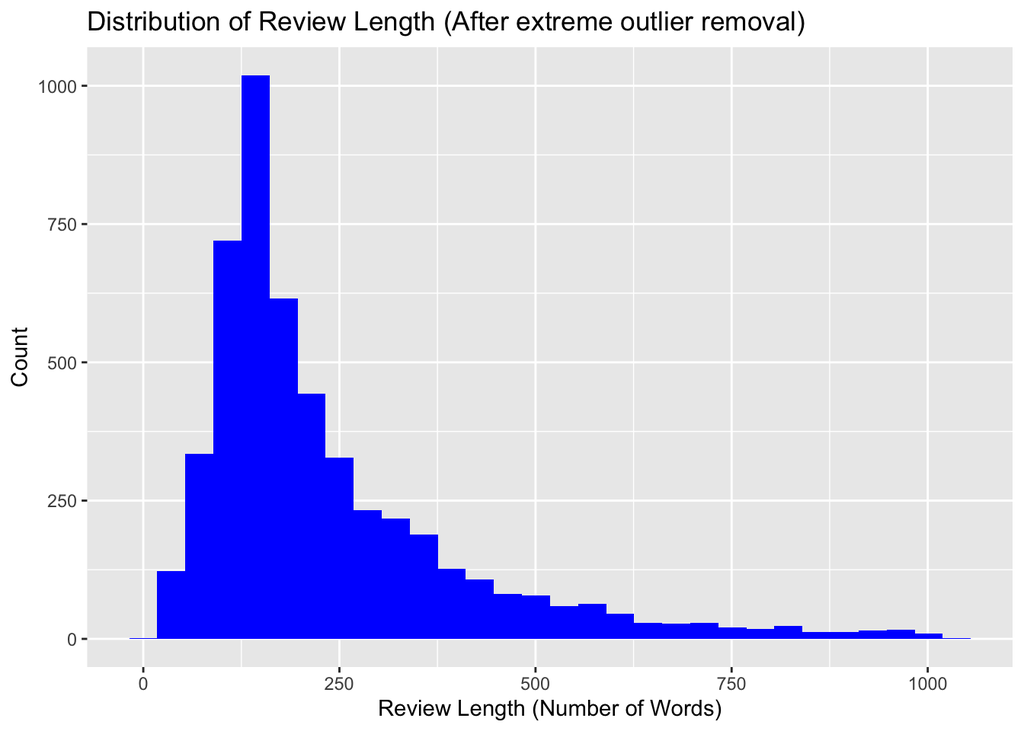

```r
movie_review_no_outliers <- movie_review%>%select(id, sentiment, review, review_length)%>%filter(review_length<1200)
ggplot(movie_review_no_outliers, aes(x = review_length)) +
  geom_histogram(fill = "blue") +
  labs(
    title = "Distribution of Review Length (After extreme outlier removal)",
    x = "Review Length (Number of Words)",
    y = "Count"
  )
```

This graph is much more zoomed in than the previous version containing the outliers, but still illustrates that the distribution of word length is far from normally distributed. In fact, this graph is heavily skewed right and shows that there is a lot more variation in the data than normal. We considered removing even more outliers, but there was no evident gap indicating outliers in this graph anymore, so we decided it was best to keep the data as is. This led us to use tf-idf for our text representation method because this is a normalized word count for each review, so it takes into consideration that some reviews are longer than others, without assigning more weight to longer reviews.

Moreover, we analyzed the review length statistics, which reveal a broad spectrum of review lengths, ranging from a minimum of 12 words to a maximum of 2470 words. The median review length of 177 words indicates that half of the reviews are shorter than this, while the mean review length of 237.5 words represents the dataset’s average length.

```r
summary_review_length <- summary(movie_review$review_length)
print(summary_review_length)
```

```
   Min. 1st Qu.  Median    Mean 3rd Qu.    Max.
   12.0   128.0   177.0   237.5   293.0  2470.0
```

# Text pre-processing

**Further Preprocessing**  
To begin our text preprocessing, we organized the reviews into a corpus, which stores the collection of reviews as raw character strings and some metadata. We then preprocessed our data by converting the text to lowercase, removing punctuation and numbers, as well as stop words to limit the clustering models from being influenced by differences in grammar or the use of stop words.

```r
reviews_corpus <- Corpus(VectorSource(movie_review_no_outliers$review))
reviews_corpus <- tm_map(reviews_corpus, content_transformer(tolower))
reviews_corpus <- tm_map(reviews_corpus, removePunctuation)
reviews_corpus <- tm_map(reviews_corpus, removeNumbers)
reviews_corpus <- tm_map(reviews_corpus, removeWords, stop_words$word)
reviews_corpus
```

```
<<SimpleCorpus>>
Metadata:  corpus specific: 1, document level (indexed): 0
Content:  documents: 4996
```

The tm_map function in R has a dictionary of stop words that it uses to remove these from the corpus, however, we were also curious to see if there were any words specific to movie review context that added little value to distinguishing reviews. To do this, we tokenized the data and plotted the frequencies of the 30 most commonly used words in the review (shown below)

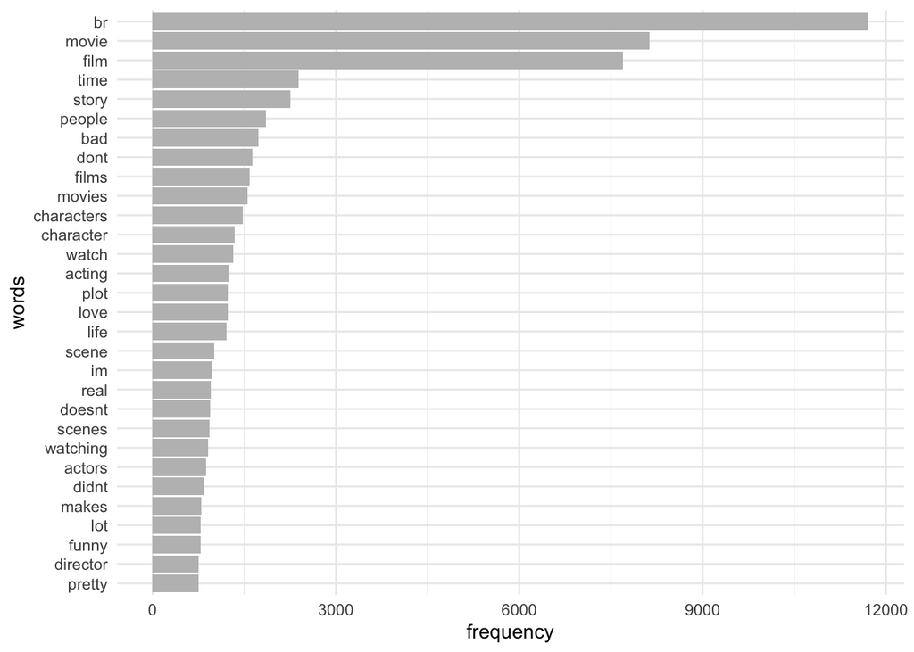

```r
#The following variables are only created for visualization purpose, but for the analysis we will simply use the reviews_corpus

reviews_text <- sapply(reviews_corpus, as.character)
reviews_df <- data.frame(review = reviews_text)
review_tokenized <- reviews_df %>%
  unnest_tokens(word, review)

#Make a bar plot to visualize our findings (only using the 30 most common words)
review_tokenized |>
  count(word) |>
  arrange(desc(n)) |>
  head(30) |>
  ggplot(aes(x = n, y = reorder(word, n))) +
  geom_col(fill="gray") +
  labs(x = "frequency", y="words") +
  theme_minimal()
```

This bar chart shows that words like ‘movie’, ‘film’, and ‘br’ (representing a break) were used a lot. Consequently, we added these to our own dictionary of additional stop words to remove from the corpus.

```r
#To add our choice of words to the dataset 'stopwords'
custom_stopwords <- c("br", "movie", "movies", "film", "films")
for (word in custom_stopwords) {
  reviews_corpus <- tm_map(reviews_corpus, removeWords, word)
}
```

We now see that the most common words are relevant to the individual reviews.

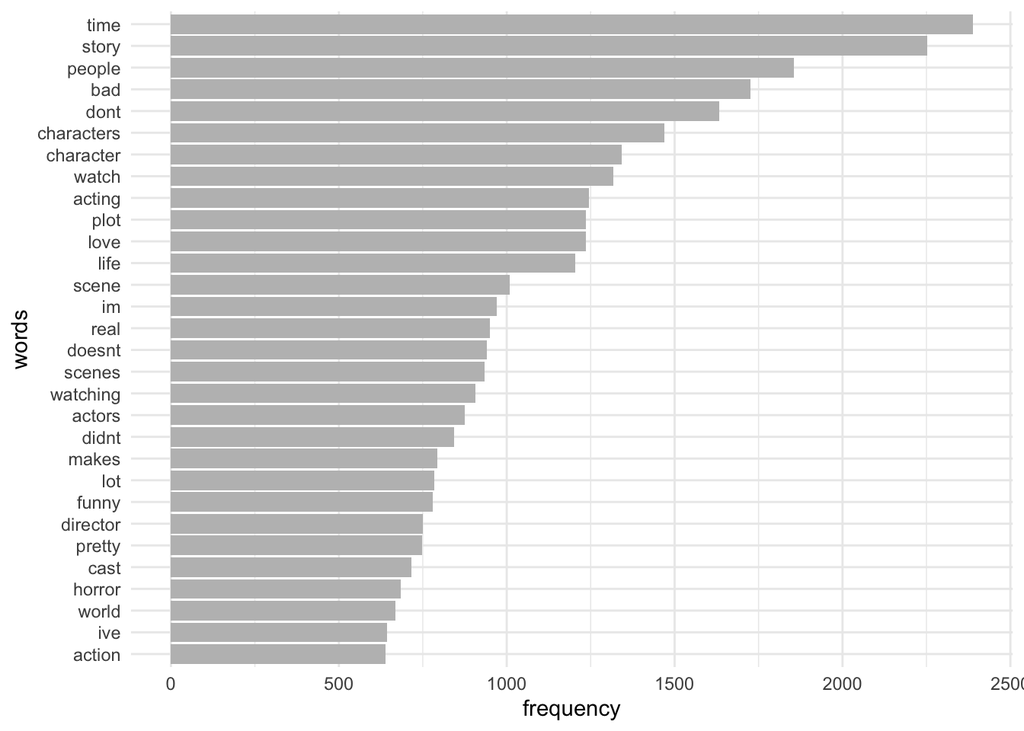

```r
reviews_text <- sapply(reviews_corpus, as.character)
reviews_df <- data.frame(review = reviews_text)
review_tokenized <- reviews_df %>%
  unnest_tokens(word, review)

#Make a bar plot to visualize our findings (only using the 30 most common words)
review_tokenized |>
  count(word) |>
  arrange(desc(n)) |>
  head(30) |>
  ggplot(aes(x = n, y = reorder(word, n))) +
  geom_col(fill="gray") +
  labs(x = "frequency", y="words") +
  theme_minimal()
```

With the corpus now only containing relevant words, text preprocessing is concluded and a text representation can be applied.

# Text representation

We used the TF-IDF (Term Frequency-Inverse Document Frequency) text representation method to analyze movie reviews. TF-IDF is a technique used to convert text documents into a numerical matrix. We selected this method due to its normalization capability, which enables comparison between reviews of different lengths.

Furthermore, we have taken a sample of the data, since the models take a lot of time to run when using all the data points. For now we have set the sample size to 1500, but this may be adapted. We recognize that there is a large possibility that this will skew our model performance results. However, we believed it was more important to focus on the text representation and modeling process than the outcome of the clusters, and therefore decided that this was necessary in order for everything to run in a timely manner.

To continue, we then made a Document Matrix Term (DTM) of the sampled data. This is basically a word count of each word being a column and each document (review in our case) being a row. This DTM has been standardized to a TF-IDF to ensure fairness across different review lengths.

```r
data_subset_idx <- sample(length(reviews_corpus), 1500)
sampled_data <- reviews_corpus[data_subset_idx]

reviews_dtm <- DocumentTermMatrix(sampled_data)
reviews_tfidf <- weightTfIdf(reviews_dtm)
data <- as.data.frame(as.matrix(reviews_tfidf))
distances <- dist(data)
```

# Text clustering

Regarding clustering methods, we looked into agglomerative hierarchical, k-means, Gaussian Mixture Models and k-medians clustering. For each method, we performed a model for 5 and 10 clusters and we evaluated those in the Evaluation section. In this section we will dive into each of the mentioned clustering methods.

**Agglomerative hierarchical clustering**  
Agglomerative clustering is a hierarchical method that merges individual data points into successively larger clusters. This approach is bottom-up and therefore starts by considering each data point as a single cluster. Then it iteratively merges the most similar clusters until all points belong to a single cluster, or a specified stopping criterion is met. It builds a tree-like structure (dendrogram) to illustrate the merging process, allowing for flexible interpretations of the data’s structure. Because this dataset is so large, the dendrogram contains too many merges, making it difficult to interpret. For this reason, we have chosen not to create a visualization of the dendrogram.

```r
library(ggdendro)
result <- hclust(distances, method = "complete")

k <- c(5,10)
hier_df <- data.frame(k=numeric(0), dunn_index=numeric(0), avg_silhouette=numeric(0))
for (i in k){
  hier_model <- cutree(result, i)
  dunn_index_hier <- cluster.stats(distances, hier_model)$dunn2
  hier_sil <- silhouette(hier_model, distances)
  sil_widths_hier <- mean(hier_sil[, 3])
  hier_df <- rbind(hier_df, data.frame(k=i, dunn_index=dunn_index_hier, avg_silhouette=sil_widths_hier))
  }
hier_df
```

| k | dunn_index | avg_silhouette |
| --- | --- | --- |
| 5 | 1.738906 | 0.4258534 |
| 10 | 1.598645 | 0.3745906 |

**K-means clustering**  
In k-means clustering, we randomly assign examples to a *k* number of clusters. Then we calculate the centroid (i.e. mean) within each clusters and assign each example to the cluster belonging to its closest centroid. Then the centroids are recalculated, and this process repeats itself until the examples are no longer assigned to other clusters.

```r
#loop for fitting k means with different k values and determining optimal value of k
k <- c(5,10)
kmeans_df <- data.frame(k=numeric(0), dunn_index=numeric(0), avg_silhouette=numeric(0))
for (i in k){
  kmeans_model <- kmeans(data, centers = i)  # Clustering based on 'n' and 'tf_idf' columns
  dunn_index_kmeans <- cluster.stats(d=distances, kmeans_model$cluster)$dunn2
  km_sil <- silhouette(kmeans_model$cluster, distances)
  sil_widths_kmeans <- mean(km_sil[, 3]) #taking the average of the silhouette scores for each data point
  kmeans_df <- rbind(kmeans_df, data.frame(k=i, dunn_index=dunn_index_kmeans, avg_silhouette=sil_widths_kmeans))
  }
kmeans_df
```

| k | dunn_index | avg_silhouette |
| --- | --- | --- |
| 5 | 1.738906 | 0.4258534 |
| 10 | 1.598645 | 0.3745906 |

**K-medians clustering**  
After noticing that the GMM yield a null output, we decided to add another clustering method in order to have some more data to compare the different methods. Since k-medians looks a lot like k-means, it was an easy choice to see what the difference would be. K-medians is almost the same as the k-means, but it only differs in the fact that the center of the cluster is the median and not the mean.

```r
library(Kmedians)
k <- c(5, 10)
kmedians_df <- data.frame(k = numeric(0), dunn_index = numeric(0), avg_silhouette = numeric(0))

for (i in k) {
  kmed_model <- pam(distances, k = i)
  dunn_index_kmed <- cluster.stats(d = distances, kmed_model$cluster)$dunn2
  kmed_sil <- silhouette(kmed_model$cluster, distances)
  sil_widths_kmed <- mean(kmed_sil[, 3])  # Taking the average of the silhouette scores for each data point
  kmedians_df <- rbind(kmedians_df, data.frame(k = i, dunn_index = dunn_index_kmed, avg_silhouette = sil_widths_kmed))
}

# Print the K-medians results
kmedians_df
```

| k | dunn_index | avg_silhouette |
| --- | --- | --- |
| 5 | 1.738906 | 0.4258534 |
| 10 | 1.598645 | 0.3745906 |

# Evaluation & model comparison

To enhance the quality and extent of our model evaluation, we decided to consider two performance metrics: Dunn index and silhouette coefficients. To begin with, the Dunn index takes both within-cluster separation and between-cluster separation into account. This is important because the goal of any clustering algorithm is to create clusters in which the points within each cluster are close together but are far away from points in other clusters. The Dunn index is calculated by taking the minimum between-cluster distance and dividing it by the maximum within-cluster distance. Ideally, the between-cluster distance is large, and the within-cluster distance is small, suggesting that higher values of the Dunn index indicate better separated and compact clusters. The Dunn index can be calculated in R using the cluster.stats() function from the fpc library. We applied this function to each of our working models and found that the Dunn index was the highest for k = 5 and the same for every clustering method (1.738906 for k = 5 and 1.598645 for k = 10).

Moreover, we also compared silhouette scores for each of our models. While DB index considers average similarity within and between clusters, silhouette coefficient measures how well each data point belongs to its cluster. Thus, each point receives a score ranging from -1 to 1 where values of 1 indicate that that point is well assigned, 0 meaning that point could have been assigned to multiple clusters, and -1 indicating that point was misassigned. In order to compare silhouette scores to DB index values, the mean of all silhouette scores for each point is taken to represent how well a particular model clusters points overall. In R, silhouette scores can be calculated for each point using the cluster.stats() function from the fpc library as well, but extracting sil_width instead of db and taking the mean of this vector. We followed this process for each of our models and found that the silhouette coefficient was the highest for k = 5 and the same for every clustering method (0.4258534 for k = 5 and 0.3745906 for k = 10).

In conclusion, at k = 5 all models exhibit a similar clustering pattern, reflected in identical Dunn Index and Silhouette Score. This suggests that model choice might not significantly impact results. Yet, widening the sample might alter these findings, potentially affected by different random samples and seeds.

```r
combined_df <- data.frame(model_type=numeric(0), dunn_index=numeric(0), avg_silhouette=numeric(0))
combined_df <- rbind(combined_df, data.frame(model_type='K-means', dunn_index = best_kmeans_model_vals$dunn_index, avg_silhouette = best_kmeans_model_vals$avg_silhouette))
combined_df <- rbind(combined_df, data.frame(model_type='K-medians', dunn_index = best_kmedians_model_vals$dunn_index, avg_silhouette = best_kmedians_model_vals$avg_silhouette))
combined_df <- rbind(combined_df, data.frame(model_type='Hierarchical', dunn_index = best_hier_model_vals$dunn_index, avg_silhouette = best_hier_model_vals$avg_silhouette))
combined_df
```

| model_type | dunn_index | avg_silhouette |
| --- | --- | --- |
| K-means | 1.738906 | 0.4258534 |
| K-medians | 1.738906 | 0.4258534 |
| Hierarchical | 1.738906 | 0.4258534 |

```r
best_model <- combined_df[which.max(rowSums(combined_df[, -1])), ]$model_type
#Since all models have the same scores, it does not really matter which we will choose for our final model. Let's say k-means with a k of 5.
```

# Team member contributions

Write down what each team member contributed to the project.

- Ezra Gerris: Data pre-processing, Agglomerative clustering, K-median clustering
- Julia van Heeringen: Data description, text representation, K-means clustering, GMM, Model evaluation
- Ana Melchor Perez: Data description, K-means clustering